# Ridesharing Project

## Introduction

This project conducts statistical analysis on Uber and Lyft price estimates, and seeks to find associations between price and other variables. The data comes from [Kaggle](https://www.kaggle.com/ravi72munde/uber-lyft-cab-prices), and was collected via Uber and Lyft api queries and corresponding weather conditions during a few weeks in November-December in 2018 by this [user](https://github.com/ravi72munde). Inspiration for cleaning and combining the rides and weather table came from [here](https://www.kaggle.com/tangyx233/uber-lyft-cab-prices).

## Exploratory Data Analysis

Our variable of interest is price, which ranges from $2.50 to $97.50.

- Price
- Value

Min.

2.50000

1st Qu.

9.50000

Median

16.00000

Mean

17.18493

3rd Qu.

24.00000

Max.

97.50000

The distribution of price is about the same for both Uber and Lyft

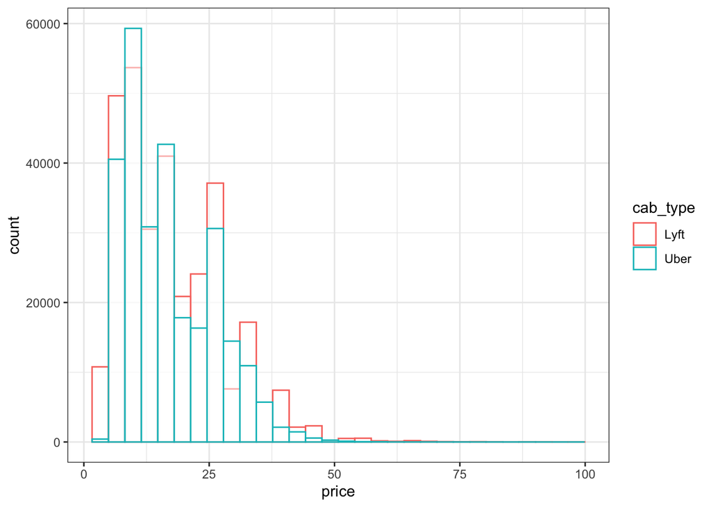

#### How does price vary by cab type?

Here is the min, max, median and mean price of a trip broken down by the vehicle type

- Uber Ride Type
- Uber Min Price
- Uber Max Price
- Uber Median Price
- Uber Mean Price

Basic

6.0

44.0

9.5

9.764805

Lux

13.5

68.5

19.5

20.520902

LuxXL

23.0

89.5

28.5

30.286003

Shared

4.5

42.5

8.5

8.752105

XL

8.0

76.0

15.0

15.677541

- Lyft Ride Type
- Lyft Min Price
- Lyft Max Price
- Lyft Median Price
- Lyft Mean Price

Basic

5.0

38.5

9.0

9.610261

Lux

10.5

75.0

19.5

20.414669

LuxXL

26.0

97.5

30.0

32.321568

Shared

2.5

22.5

7.0

6.029331

XL

9.0

65.0

13.5

15.308207

- Lyft is comparable to UberX
- Lux Black XL is comparable to Black SUV
- Lyft XL is comparable to UberXL
- Shared is comparable to Uber Pool
- Black is comparable to Lux Black

We also combined Lux with Lux Black because they are essentially the same vehicle type minus some small difference.

Here we can clearly see how the distribution of price changes depending on the ride type.

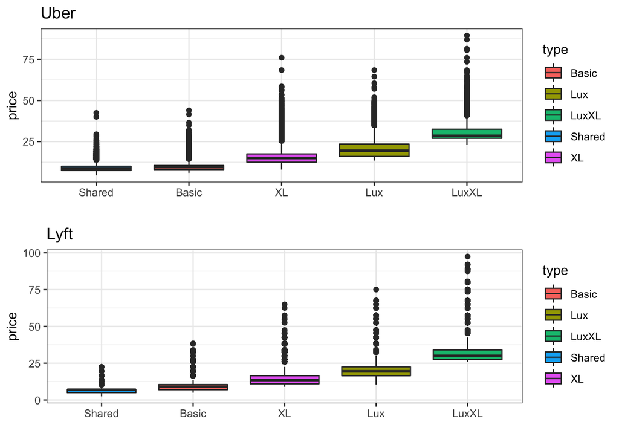

#### Distance vs Price

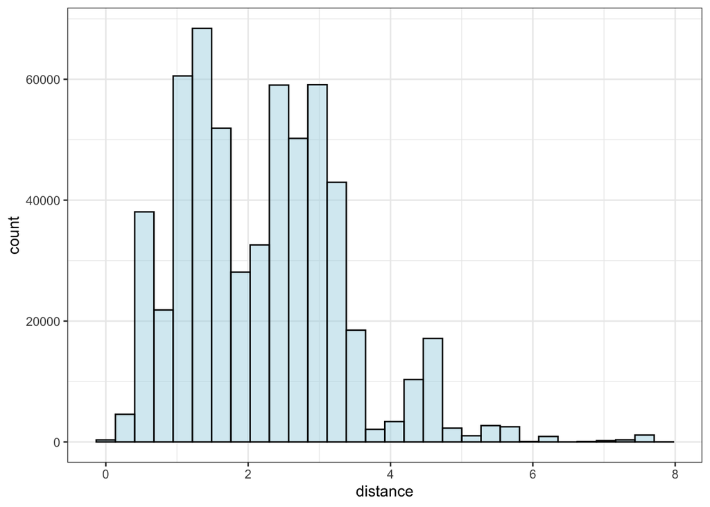

As we can see this by scatter plot, Lyft has a lower base price and also a higher price ceiling.

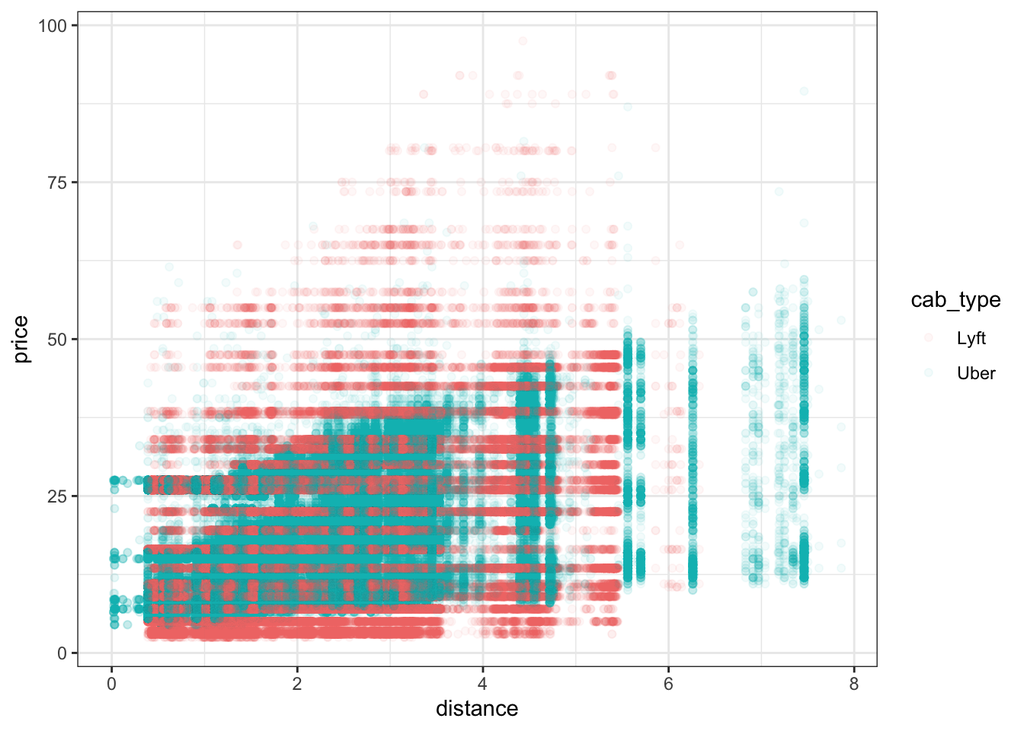

Here is a scatter plot of price vs distance broken down by ride type for both Uber and Lyft. When broken down by ride type, it becomes clear there is potentially some strong positive linear relationship between price and distance.

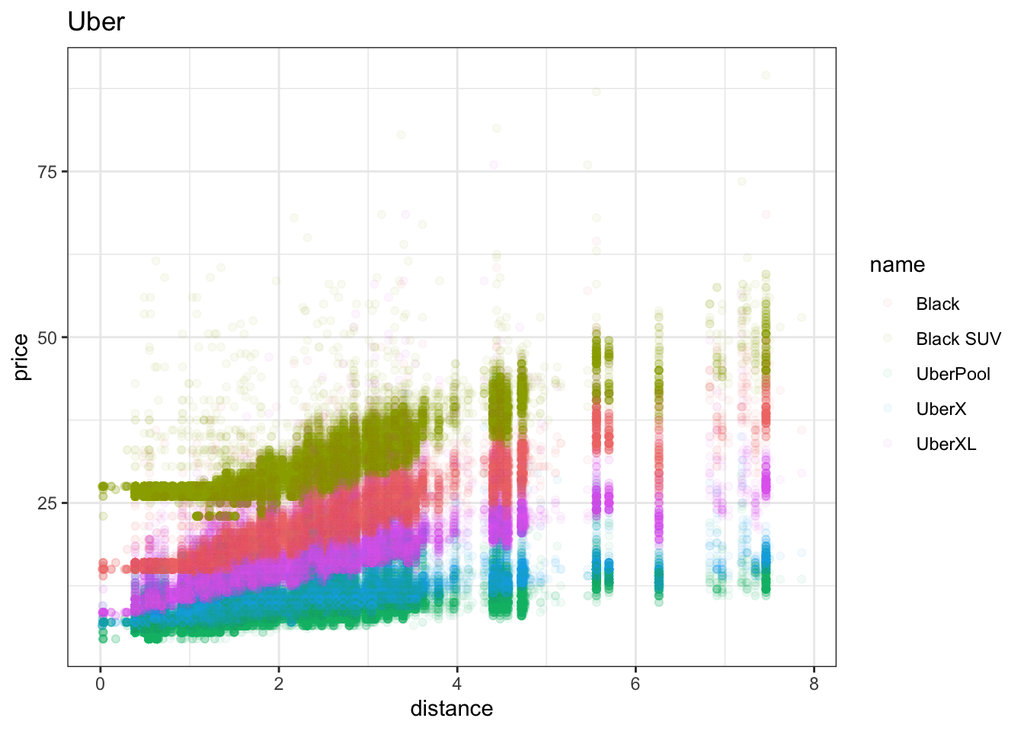

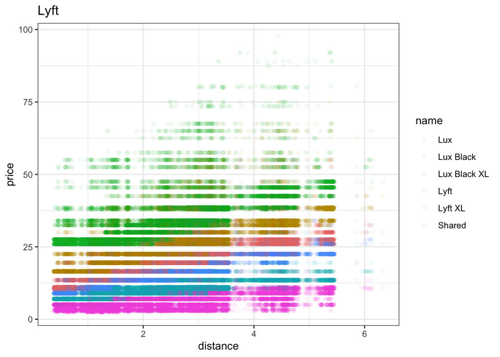

| Price.Vs.Distance | Lyft | LuxBlack | LuxBlackXL | Lux | LyftXL | Shared |
| --- | --- | --- | --- | --- | --- | --- |
| Lyft | 0.7798634 |  |  |  |  |  |
| Lux Black |  | 0.8132575 |  |  |  |  |
| Lux Black XL |  |  | 0.6973414 |  |  |  |
| Lux |  |  |  | 0.8366301 |  |  |
| Lyft XL |  |  |  |  | 0.8144453 |  |
| Shared |  |  |  |  |  | 0.6420404 |

| Price.Vs.Distance | Black | BlackSUV | UberPool | UberX | UberXL | WAV |
| --- | --- | --- | --- | --- | --- | --- |
| Black | 0.9131188 |  |  |  |  |  |
| Black SUV |  | 0.8582338 |  |  |  |  |
| UberPool |  |  | 0.670947 |  |  |  |
| UberX |  |  |  | 0.7350737 |  |  |
| UberXL |  |  |  |  | 0.7859246 |  |
| WAV |  |  |  |  |  | 0.7353036 |

To confirm, there are high correlations between distance and price when broken down by ride type here.

#### Price on weekdays for Lyft

So far the comparisons have been on the base price between Uber and Lyft. We only have data on surge prices for Lyft, but not Uber. So here we make comparisons based off Lyft prices (including surge) for Lyft only.

There doesn’t seem to be an effect of the day of the week on median Surge Prices according to the data, and the weeks that it was collected. This is obviously surprising, we would expect prices to be higher on Fridays or even weekends.

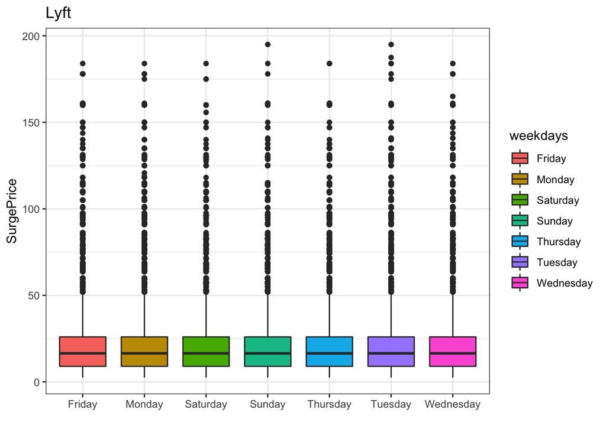

#### Price on time of day

There also doesn’t seem to be much difference in the median of surge price when it is broken down by the time of day, according to our data and the weeks it was collected.

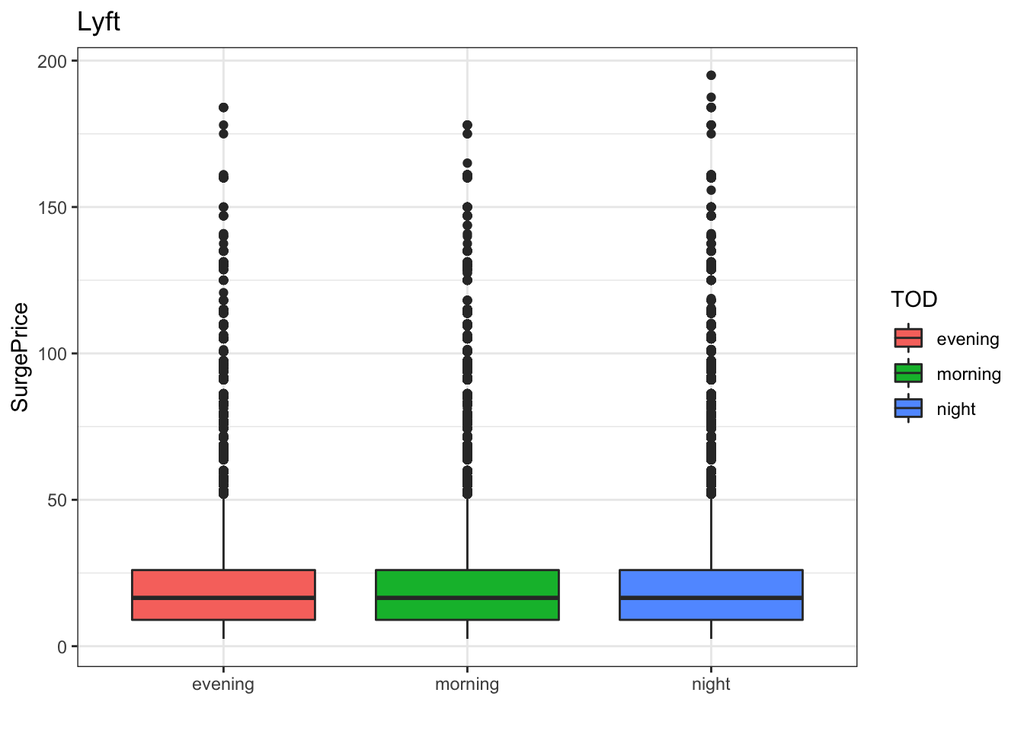

#### Mean base price of an Uber trip

Here we conduct a hypothesis test to see whether the mean base price of an Uber trip in Boston differs from $10. The null and alternative hypothesis are as follows:

$$H_{0}: \mu = 10$$

$$H_{A}: \mu \neq 10$$

```
##
##  One Sample t-test
##
## data:  price$price
## t = 415.13, df = 274279, p-value < 2.2e-16
## alternative hypothesis: true mean is not equal to 10
## 95 percent confidence interval:
##  16.9668 17.0329
## sample estimates:
## mean of x
##  16.99985
```

The conclusion is to reject the null hypothesis that the true population mean of base price for Uber is equal to $10 at all alpha levels. The p-value is essentially zero due to the large sample size and the effect size of 0.75 confirms practical significance. The confidence interval also agrees with our conclusion in that it does not contain $10.

#### Proportion of Uber X trips

Here we conduct a hypothesis test to see whether the proportion of Uber X trips in Boston is different from 0.30. The null and alternative hypothesis are as follows:

$$H_{0}: p = 0.30$$

$$H_{A}: p \neq 0.30$$

```
##
##  1-sample proportions test with continuity correction
##
## data:  as.integer(x) out of n, null probability 0.3
## X-squared = 13068, df = 1, p-value < 2.2e-16
## alternative hypothesis: true p is not equal to 0.3
## 95 percent confidence interval:
##  0.1984763 0.2014737
## sample estimates:
##         p
## 0.1999708
```

The conclusion is to reject the null hypothesis that the true population proportion of Uber X trips is equal to 0.30 at all alpha levels. The p-value is essentially zero due to the large sample size and the effect size of 0.18 says there is little practical significance. The confidence interval also agrees with our conclusion in that it does not contain 0.30.

#### Is the mean estimated price different between Uber and Lyft?

The null and alternative hypothesis are as follows

$$H_{0}: \mu_{U}-\mu_{L} = 0$$

$$H_{A}: \mu_{U}-\mu_{L} \neq 0$$

```
##
##  Welch Two Sample t-test
##
## data:  mergeDF$price[mergeDF$cab_type == "Uber"] and mergeDF$price[mergeDF$cab_type == "Lyft"]
## t = -14.184, df = 580226, p-value < 2.2e-16
## alternative hypothesis: true difference in means is not equal to 0
## 95 percent confidence interval:
##  -0.3994214 -0.3024348
## sample estimates:
## mean of x mean of y
##  16.99985  17.35078
```

The conclusion is to reject the null hypothesis that the true population difference in mean estimated price between Uber and Lyft is equal to 0 at all alpha levels. The p-value is essentially zero due to the large sample size and the effect size of 0.11 says there may be little practical significance. The confidence interval also agrees with our conclusion in that it does not contain 0. Additionally, the mean difference shows that Lyft has higher prices on average.

The first model just regresses price on cab type.
*Model 1*:
$$\begin{equation}
\hat{Price}_i = \hat{\beta}_0 + \hat{\beta}_1 Uber_i
\end{equation}$$

The second model controls for distance.
*Model 2*:
$$\begin{equation}
\hat{Price}_i = \hat{\beta}_0 + \hat{\beta}_1 Uber_i + \hat{\beta}_2 Dist_i
\end{equation}$$

The Third model controls for distance and the ride type.
*Model 3*:
$$\begin{align*}
\hat{Price}_i = \hat{\beta}_0 + \hat{\beta}_1 Uber_i + \hat{\beta}_2 Dist_i +\sum_{j=1}^{i}\hat{\beta_3}_j {Vehicle_i}_j \\
\end{align*}$$

**Regression Results**

*Dependent variable:*

Price

- Model 1
- Model 2
- Model 3

(1)

(2)

(3)

Uber

-0.35

-0.36

0.24

p = 0.00***

p = 0.00***

p = 0.00***

Distance

2.97

2.97

p = 0.00***

p = 0.00***

Lux

10.80

p = 0.00***

Lux XL

21.58

p = 0.00***

Shared

-2.25

p = 0.00***

XL

5.81

p = 0.00***

Constant

17.35

10.86

3.07

p = 0.00***

p = 0.00***

p = 0.00***

Observations

580,382

580,382

580,382

R<sup>2</sup>

0.0003

0.13

0.87

Adjusted R<sup>2</sup>

0.0003

0.13

0.87

*Note:*

p<0.1; p<0.05; p<0.01

To also confirm that time of day as well as the day of the week has no effect on surge prices we ran the following regression:

*Surge Price Model*:
$$\begin{align*}
\hat{Price}_i = \hat{\beta}_0 + \hat{\beta}_1 Dist_i +\sum_{j=1}^{i}\hat{\beta_2}_j {Vehicle_i}_j +\sum_{j=1}^{i}\hat{\beta_3}_j {TOD_i}_j +\sum_{j=1}^{i}\hat{\beta_4}_j {Weekday_i}_j\\
\end{align*}$$

**Regression Results**

|  | *Dependent variable:* |
| --- | --- |
|  | Price |
| Distance | 3.67 |
|  | p = 0.00*** |
| Lux | 11.43 |
|  | p = 0.00*** |
| Lux XL | 24.04 |
|  | p = 0.00*** |
| Shared | -4.15 |
|  | p = 0.00*** |
| XL | 6.06 |
|  | p = 0.00*** |
| Morning | 0.01 |
|  | p = 0.78 |
| Night | -0.04 |
|  | p = 0.38 |
| Monday | 0.02 |
|  | p = 0.69 |
| Saturday | 0.01 |
|  | p = 0.87 |
| Sunday | 0.01 |
|  | p = 0.80 |
| Thursday | 0.001 |
|  | p = 0.99 |
| Tuesday | 0.09 |
|  | p = 0.09* |
| Wednesday | 0.08 |
|  | p = 0.18 |
| Constant | 2.13 |
|  | p = 0.00*** |
| Observations | 306,102 |
| R<sup>2</sup> | 0.59 |
| Adjusted R<sup>2</sup> | 0.59 |
| *Note:* | p<0.1; p<0.05; p<0.01 |

#### Conclusion

The effect of Uber on the first model is -0.35, which is just the difference in means of estimated price between Uber and Lyft. This suggest that the base price of Uber is on average -$0.35 less than Lyft’s base price. Adding distance to the second model doesn’t do much to the coeffcient on Uber, but distance is statistically significant. Now when we control for the vehicle type of the cab, that’s when we see the difference in means switch signs, suggesting that controling for distance and vehicle type, Uber is on average $0.24 more than Lyft’s base price. When looking at the surge price model, we do confirm there is no effect of the time of day and the day of the week on surge price estimates in Boston, which is consistent with our boxplots above.